# Exploratory Data Analysis

To understand the problem, we must understand the students and their needs.

The first question that came to mind was: **How many questions to the users have?**

To answer this, I could simply calculate the average by users, but it wouldn’t be impactful. Here are two histograms that highlight the number of questions students have.

## Number of Questions

```r
questions <- questions %>%
  mutate(date_start = as.numeric(as.Date(as.POSIXlt(questions_date_added))))

# Create a table for the minimum occurence
min_table <- questions %>%
  group_by(questions_author_id) %>%
  summarise(min = min(date_start))

questions <- merge(questions, min_table, by = "questions_author_id")

# Recombine both datasets to include the min for each
questions <- questions %>%
  mutate("elapsed_days" = (date_start - min))

# Total questions per day
dummy <- questions %>%
  mutate(questions_author_id = as.factor(questions_author_id)) %>%
  group_by(questions_author_id,date_start) %>%
  summarise(total_questions = n())

new_dummy <- distinct(merge(dummy,questions, by=c("questions_author_id","date_start"))[,c('questions_author_id','elapsed_days','total_questions')])
```

Data Tables is a great way to explore a data frame! Simply load the library (DT).

```r
new_dummy %>%
  datatable()
```

|  | questions_author_id | elapsed_days | total_questions |
| --- | --- | --- | --- |
| 1 | 0001a66883f74e8d91884fc6ea0d66a7 | 0 | 2 |
| 2 | 0004592176864233990d949862baa2f3 | 0 | 1 |
| 3 | 001bd6f7f1ac4897b0b35dc665c64d2e | 0 | 2 |
| 4 | 001bd6f7f1ac4897b0b35dc665c64d2e | 30 | 2 |
| 5 | 001d1629d09d441a8f09e3bfa884e6b9 | 0 | 2 |
| 6 | 001df2a2cfb74ef78f3053ddee305ba6 | 0 | 1 |
| 7 | 001df2a2cfb74ef78f3053ddee305ba6 | 7 | 1 |
| 8 | 001f3b39d8884a41ab7e71789b6a53a0 | 0 | 2 |
| 9 | 0029e4c8e1c14b12be6d1d9a61c55cc0 | 0 | 1 |
| 10 | 0029e4c8e1c14b12be6d1d9a61c55cc0 | 9 | 1 |

[output cut: 15301 more lines]

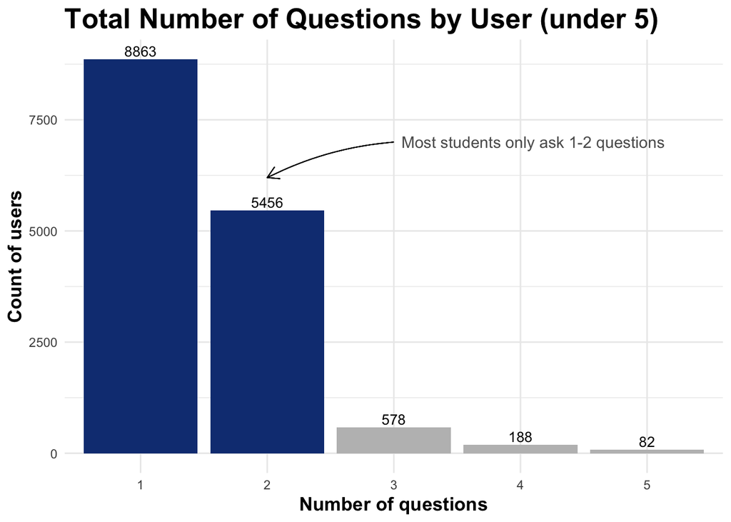

```r
# Looking at the top 5
dummy_1 <- new_dummy %>%
  filter(total_questions < 6) %>%
  group_by(total_questions) %>%
  summarize(freq = n()) %>%
  mutate(total_questions = as.factor(total_questions))

ggplot(data = dummy_1, aes(x=total_questions,  y=freq, fill = total_questions)) +
  geom_bar(stat="identity") +
  geom_text(aes(label=freq), vjust=-0.3, size=3.5) +
  theme_minimal() +
  theme(axis.title = element_text(face = "bold", size = 13),
        title = element_text(face = "bold", size = 16),
        legend.position = "none") +
  labs(title="Total Number of Questions by User (under 5)", x = "Number of questions", y = "Count of users") +
  scale_fill_manual(values=c("#133d82","#133d82","grey","grey","grey"), aesthetics = "fill")+
  geom_curve(x = 3, xend = 2, y = 7000, yend = 6200, size = .3,
             arrow = arrow(length = unit(.03, "npc")),
             curvature = 0.1) +
  annotate("text", x = 4.1, y = 7000, label = "Most students only ask 1-2 questions",
           color = "#5b5b5b")
```

```r
# Annotation style inspired by Michael Johnson (https://www.kaggle.com/mistermichael/careervillage-exploration)
```

Looking at the trailing histogram, we can see that for some cases, students may have many many questions. These students probably need better guidance or maybe their questions weren’t answered?

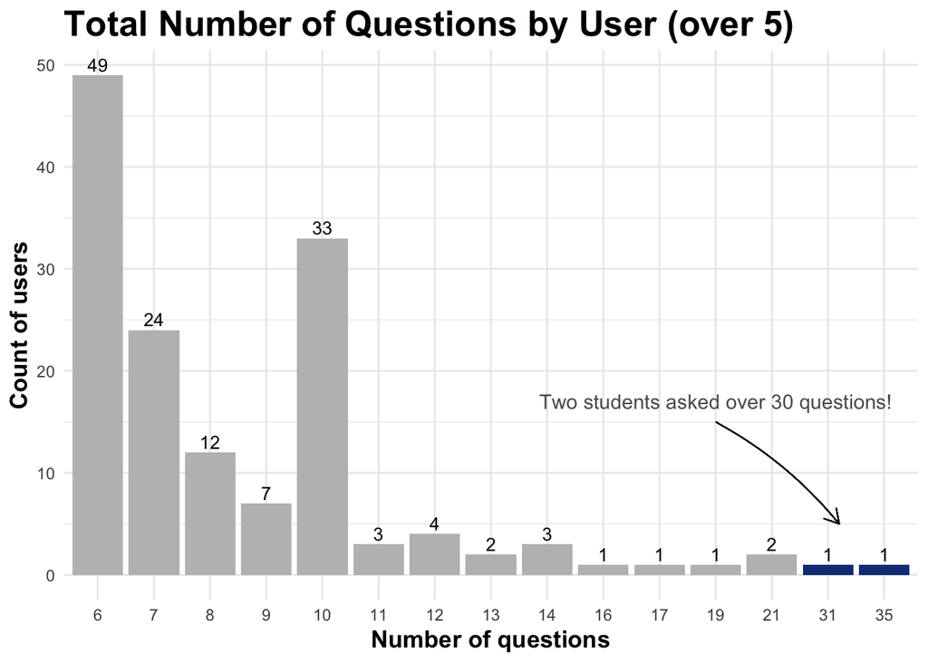

```r
dummy_2 <- new_dummy %>%
  filter(total_questions > 5) %>%
  group_by(total_questions) %>%
  summarize(freq = n()) %>%
  mutate(total_questions = as.factor(total_questions))

# Continuation of the analysis for people who asked over 5 questions

ggplot(data = dummy_2, aes(x=total_questions,  y=freq, fill = total_questions)) +
  geom_bar(stat="identity") +
  geom_text(aes(label=freq), vjust=-0.3, size=3.5) +
  theme_minimal() +
  theme(axis.title = element_text(face = "bold", size = 13),
        title = element_text(face = "bold", size = 16),
        legend.position = "none") +
  labs(title="Total Number of Questions by User (over 5)", x = "Number of questions", y = "Count of users") +
  scale_fill_manual(values=c("grey","grey","grey","grey","grey","grey","grey","grey","grey","grey",
                             "grey","grey","grey","#133d82","#133d82"), aesthetics = "fill") +
  geom_curve(x = 12, xend = 14.2, y = 15, yend = 5, size = .3,
             arrow = arrow(length = unit(.03, "npc")),
             curvature = -0.1) +
  annotate("text", x = 12, y = 17, label = "Two students asked over 30 questions!",
           color = "#5b5b5b")
```

Now I am curious to understand what is the pattern of the students who have many questions. **Do they ask them all at once? Do they ask the questions periodicaly?**

The following graph will help us understand.

I will only filter on those who have recuring questions over a 30 day period. I will also only look at a few, and see if there is anyting abnormal.

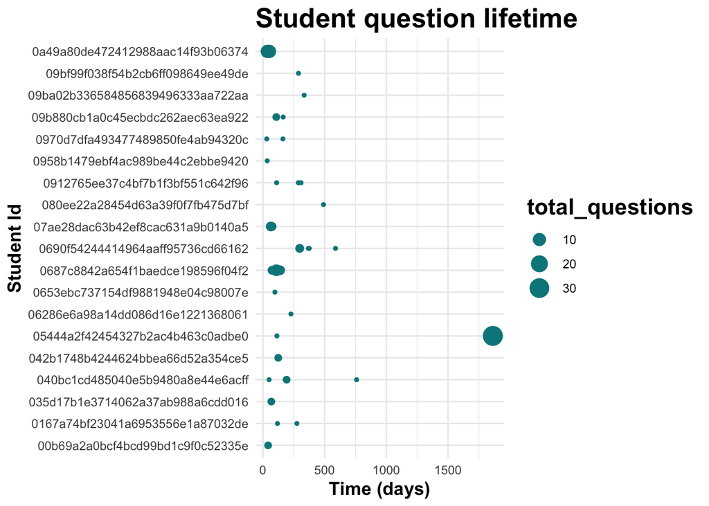

```r
filtered_dummy <- new_dummy %>%
  filter(elapsed_days > 30)

ggplot(data=filtered_dummy[0:50,], aes(x = elapsed_days, y = questions_author_id,size = total_questions))+
  geom_point(colour = "turquoise4") +
  theme_minimal() +
  labs(title="Student question lifetime",x = 'Time (days)', y= 'Student Id',color="Total Questions")+
  theme(axis.title = element_text(face = "bold", size = 13),
        title = element_text(face = "bold", size = 16))
```

Wow, some students have a lot of questions! I think it would be interesting to merge other datasets, and see the hashtags of those questions. Maybe they have something in common?

More to come…

Thanks!

Follow me on IG ! @data_culture